# POLS 1600: Final Paper

JD Calvelli

## Introduction

Candace Owens is a Black ultra-right wing conservative political pundit, who is outspoken in her criticism of liberal ideologies like structural, systemic level, racism and inequality, and identity politics. She openly rejects the Black Lives Matter movement, the Me Too movement, and social welfare on the grounds that movements and policies of these kinds promote an undeserved victim mentality amongst individuals they are intended to help support and uplift<sup>4</sup>. In this way, she stands in stark contrast to the preeminent zeitgeist political position of the majority of minority groups, and Black Americans in particular, in the United States. However, she is not universally rejected by minority individuals, nor is she misrepresentative of a subset of the voting minority population; Trump supporting, conservative Black Americans exist, and make up approximately 8 percent of the Black voting community<sup>1</sup>. What incentive could be strong enough to persuade minority individuals away from voting in accordance with what is perceived as the best course of action for their communities by the individuals within the communities themselves? At what point do minority individuals begin to stop voting in accordance with the policies that seem to be the most supportive of their socially constructed racial identity? In 1961, Robert Dahl approached a similar question with regards to White ethnic minorities, like Irish and Italian immigrants, and reached the conclusion that economic status is the determining factor behind a shift away from the centrality of ethnic identity to voting practices. Specifically, he argues that as an ethnic group progresses through three stages of economic growth, the centrality of their ethnic identity to their voting practices decreases, and economic concerns become the most salient ones for the purpose of informing voting practices<sup>2</sup>. This paper intends to examine the extent to which this argument holds true for modern racial and ethnic minorities through the examination of the linear model mapping the interactions between economic strata and salience of racial identity first across all races, then by introducing controls for the potential confounding factors of education and political partisanship to the model. Then, using this controlled model, the interaction between race importance and reported race well be examined to see how the relationship between income and race importance differs among specific racial categories, as opposed to just across all races in general. Finally, though Dahl’s argument implies a linear relationship, the potential for a quadratic relationship to be governing the interaction between economic strata and the centrality of race to identity will be examined for comparison.

## Data

The data to be used for this paper is from the What the Hell Happened Project (WTHH), a subsidiary project of the progressive Data for Progress Project, intending to capture the reasoning behind the, at the time, baffling election of Donald Trump in 2016, and the resultant down-ticket rise of new populism throughout American democracy. Specifically, they draw their data from a set of interviews conducted by YouGov, an international data analytics firm, and their ultimate sample data set data was chosen based on age, sex, race, education, urban/rural status, partisanship, marital status, and Census region in such a way as to be maximally representative of American voters in 2018<sup>3</sup>. Insofar as the primary outcome of this paper is to determine the extent to which economic status affects importance or racial identity, the dependent variable in question, or the variable on which the effects of other variables are to be tested, is some measure of the importance of racial identity. In the WTHH data, this variable is coded as RACE_IDENT, recoded to race_imp for simplicity. The variable encapsulates a survey taker's response to the question of how important being their particular race is to their identity, and is measured on an ordinal scale from 1 to 4, with 1 corresponding to the fact that it is not at all important to their identity, and 4 corresponding to the fact that it is very important to their identity. The independent variable, or the variable whose effects on the dependent variable are to be examined, are income, educ4, pid3new, and race_c. Income is the first dependent variable to be examined; it is recoded from faminc_new so as to reflect NA answers, and is an ordinal number representative of the survey taker's annual yearly income, with 1 representing an income of below 10,000 dollars, and 16 representing an income of above 500,000 dollars. The two covariates, or potential confounding variables, or other variables that might potentially have an impact on the dependent variable, are educ4 and pid3new, which represent the highest level of education the survey taker has achieved, and the survey taker’s political alignment respectively. The first covariate, educ4 is an ordinal variable, with 1 representing that the survey taker has completed high school or less education, and 4 representing that the survey taker has completed a postgraduate degree. The second covariate, pid3new, is a recode from pid7, is a character string representing a certain political ideology. All democrat leaning individuals, as established by anyone answering 1 to 3 on the pid7 ideology scale, are grouped under the title “Dem” in pid3new, and Independents and Republicans are grouped in a similar manner under “Indep” and “Repub” respectively. Finally, race_c is a recode from race to turn numeric representations into character representations; individuals who marked 1 on the race scale are represented as White in the race_c scale, those who marked 2 are represented as Black, those who marked 3 are represented as Hispanic/Latino, those who marked 4 are represented as Asian, and those who marked any other category are represented as Other.

|  | Min. | 1st Qu. | Median | Mean | 3rd Qu. | Max. | NA’s | sd |
| --- | --- | --- | --- | --- | --- | --- | --- | --- |
| race_imp_smryfull | 1 | 2 | 3 | 2.582 | 3 | 4 | 16 | 1.0220 |
| income_smryfull | 1 | 4 | 6 | 6.723 | 9 | 16 | 416 | 3.3353 |
| educ4_smryfull | 1 | 2 | 2 | 2.464 | 3 | 4 | 0 | 0.9286 |

| Dem | Indep | Repub | NA’s |
| --- | --- | --- | --- |
| 1568.0000 | 285.0000 | 1341.0000 | 21.0000 |
| 0.4877 | 0.0886 | 0.4171 | 0.0065 |

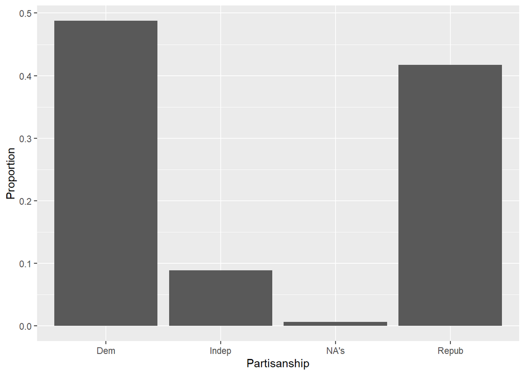

This second table and plot provide summary statistics for the pid3new variable, namely the number and percentage of individuals who fall into the three political alignments. The majority of the sample, at 49 percent, identify as Democrats, whereas 42 percent of the sample identified as Republican, and 9 percent identify as Independent, with less than 1 percent of the sample opting not to respond.

| White | Black | Hispanic/Latino | Asian | Other |
| --- | --- | --- | --- | --- |
| 2607.0000 | 264.0000 | 164.000 | 37.0000 | 143.0000 |
| 0.8109 | 0.0821 | 0.051 | 0.0115 | 0.0445 |

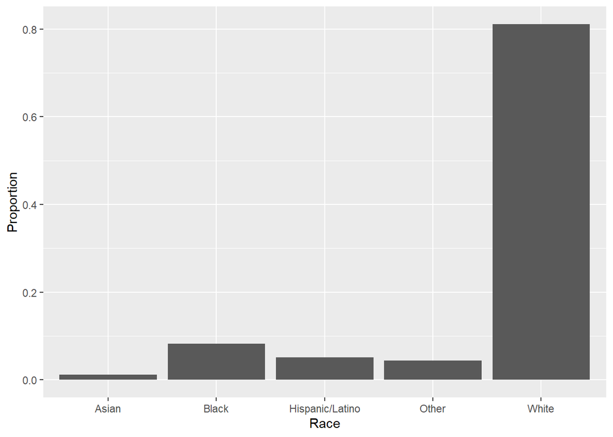

This third table and plot provide summary statistics for the race_c variable, namely the number and percentage of individuals who fall into the 5 racial categories captured by the race_c variable. The vast majority of the sample, at 81 percent, identified as “White,” whereas 8 percent, 5 percent, and 1 percent of the sample identified as Black, Hispanic/Latino, and Asian respectively. Finally, 5 percent of the sample identified as Other racial categories.

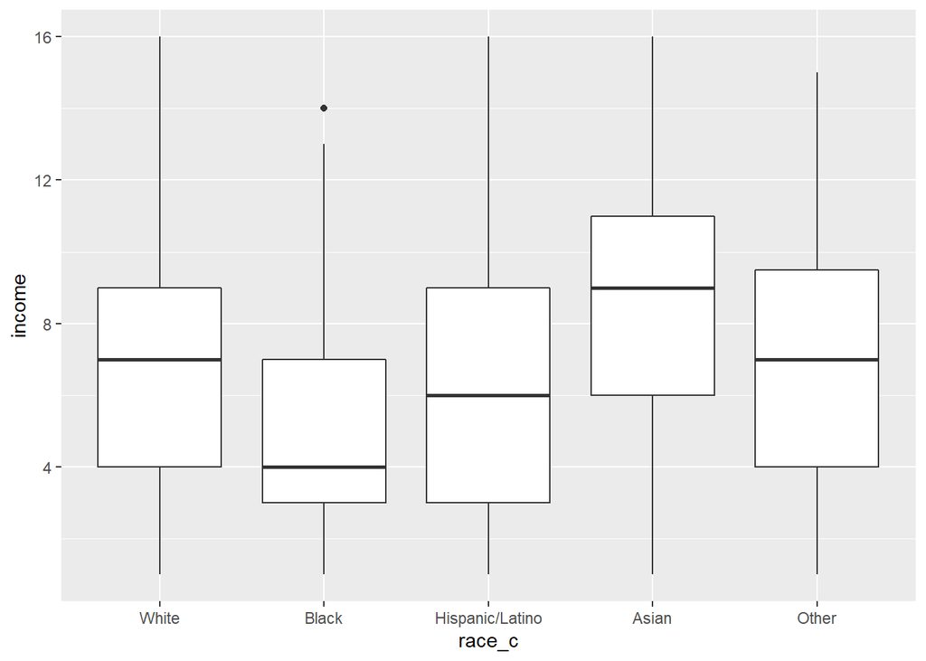

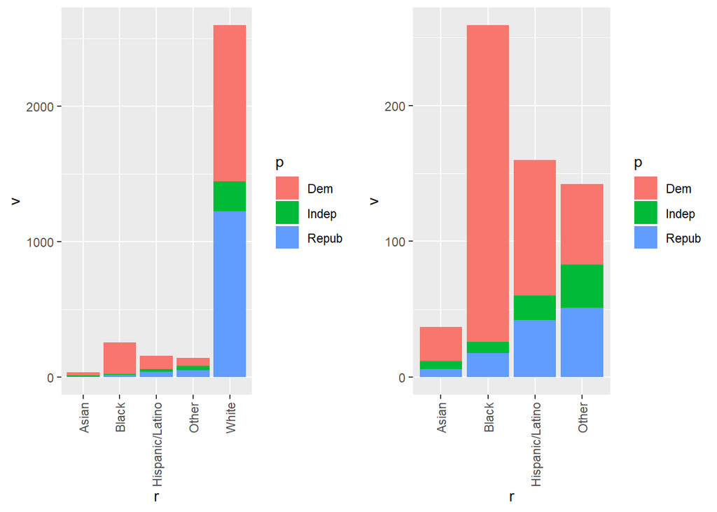

This final graph demonstrates the composition of Democrats, Independents, and Republicans within any individual racial category. Given the size of the White category, the second graph removes the White category so as to better view the composition of the minority categories. This data demonstrates that the majority of minority individuals self identify as Democratic, especially amongst Black individuals, whereas there seems to be a more even distribution of Democrats, Independents, and Republicans for the White category. Given that identity politics are, in the cultural zeitgeist, considered to be progressive ideals of the Democratic party, it would be interesting if Dahl's theory held regarding the reduction of importance of centrality of race to identity, given this particular partisan makeup of the sample.

## Expectations and Methods

Dahl’s argument seems to imply a linear relationship between income and centrality of race to voting behavior; as the ethnic group moves upwards along the economic rungs of society, the significance of their ethnic identity decreases. As a result, the following linear model should be fit:

$$race\_imp \sim income$$

### Covariates

However, income might not be the only factor that would affect the importance of an individual’s racial identity. For example, level of education, as represented by educ4, and an individual’s partisan affiliation, as represented by pid3new, could certainly also affect the extent to which an individual views their racial identity as significant. These covariates, then, have the potential to confound the intended result of determining the extent to which income affects importance of racial identity. In order to try to account in the model for the potential affect that those potential confounding factors have on the outcome of the model, they should be introduced as covariates to be controlled for in the model:

$$race\_imp \sim income + pid3new + educ4$$

Controlling for these covariates by adding them to the model increases the accuracy of the initial claim regarding the relationship between race_c and income by holding the values that represent the supposed relationships between race_c and pid3new and educ4 constant. Doing so isolates the effect of those variables from the effect of the independent variable intended to be assessed, in this case, income. Though increase in education and partisanship will most likely also result in a decrease in centrality of race identity to individuals, if Dahl’s argument is true, then, regardless of the covariates, increase in income should still affect the centrality of race identity to individuals. In that case, the coefficients on pid3new and educ4 should be negative, but regardless, the coefficient on income should still be negative as well.

Finally, to test the extent to which this relationship varies among specific racial groups, the model should include the interactions between the racial groups and the income term:

$$race\_imp \sim income * race\_c + pid3new + educ4$$

The result will be new terms demonstrative of the extent to which the fact that an individual is a certain racial group changes the overall slope of the model, while still controlling for the confounding factors of pid3new and educ4. For example, because White is set as the reference category to which the extent to which the effect of different racial groups will be added, it could be called X. The effect that being Black has on the relationship between income and centrality to racial identity of the reference category can be called Y. Thus, the relationship between income and centrality of race to identity for “Black individuals” would be the sum of X and Y; this process will be repeated for all of the racial categories. Thus, if Dahl’s theory continues to hold, then these sums across the board should still remain negative. However, the effect that being a racial minority has on the relationship between income centrality to race identity of the reference category will most likely be positive, resulting in a less negative slope than the White reference category, and implying a lesser effect of income on the centrality of race to identity to individuals. The extent to which those effects are positive will most likely vary among the racial groups themselves. The reference category of White individuals will most likely have a low intercept and a relatively stagnant slope, implying that regardless of income, significance of racial identity will be low and remain low. However, the continuing systems of oppression in place for minority individuals would most likely result in higher intercepts and very small changes in slope from the reference category, if at all. This would imply that the centrality of race identity to individuals of minority categories should start at a higher point, and decay even slower than the reference category, if at all. However, given the colorist nature of American society, perhaps those minorities that are more easily able to be accepted into the White homogeneity as their economic standing increases by virtue of their lighter skin color will have lower intercepts and greater changes in slope from the reference category than their darker counterparts, implying a lower starting centrality of race to identity, and a more prevalent, less positive, change in the slope from the reference category than their darker counterparts.

Finally, in the event that the relationship is not linear, unlike Dahl’s implication, a quadratic relationship will also be tested:

$$race\_imp \sim (income + I(income^2))* race\_c + educ4 + pid3new$$

The result of implementing a quadratic model is that it allows the slope of the effect to differ at various levels of income, as opposed to remaining constant throughout. In this case, perhaps the model would demonstrate that across the racial categories, there will be a heightened race importance for middle class individuals, as their income bracket is less of a constant concern as it is for those in the lower class, and less of a status symbol or cause for identity formation than it is for those of extreme wealth.

## Analysis

|  | ml |  |  |  |
| --- | --- | --- | --- | --- |
| Predictors | Estimates | std. Error | CI | p |
| (Intercept) | 2.82 | 0.04 | 2.73 – 2.90 | **<0.001** |
| income | -0.03 | 0.01 | -0.04 – -0.02 | **<0.001** |
| Observations | 2788 |  |  |  |
| R<sup>2</sup> / R<sup>2</sup> adjusted | 0.011 / 0.011 |  |  |  |

This table demonstrates the results of the first model, that across all races, the intercept, or the expected mean value for race_imp if the slope of income were zero, is estimated at 2.82. The slope on income is -0.03, meaning that as the value for income increases by 1, the value for race_imp decreases by -0.03 at each stage of increase of income. The standard error, or the average distance that the actually observed values lay from the fit regression line, is 0.04 and 0.01 for the intercept and slope respectively. Lower values for standard error are preferable, as that means that the observed values are closer to the fitted regression line, meaning that the estimates of the fitted regression line are more representative of the actual data collected. The lower and upper confidence intervals for the intercept are 2.73 and 2.90 respectively, which means that the estimated value for the intercept as determined by the model lies within the confidence intervals. In other words, the estimated data lies, if the experiment were to be repeated, within the range of values expected 95 percent of the time. Similarly, the estimated value for income lies within its confidence interval of -0.04 to -0.02, and thus, similarly lies, if the experiment were to be repeated, within the range of values expected 95 percent of the time. Finally, both the p-values of the intercept and the slope are significantly less than 0.05, which is further support for the claim that there is a relationship between income and centrality of race to identity. These resultant p-values demonstrate that there is strong evidence to reject the null hypothesis that there is not a relationship between income and centrality of race to identity, or, that 95 percent of the time this data demonstrates a statistically significant relationship between income and centrality of race to identity or that the data implies that less than less than 5 percent of the time there is not a statistically significant relationship between income and centrality. In fact, not only is the data not reflective of a statistically significant relationship less than 5 percent of the time, but is, more stringently, also not reflective of a statistically significant relationship less than 0.1 percent of the time.

Statistical models

|  | **Model 1** | **Model 2** | **Model 3** |  |
| --- | --- | --- | --- | --- |
| (Intercept) | 2.8171*** | 2.9722*** | 2.5585*** |  |
|  | (0.0432) | (0.0621) | (0.0649) |  |
| income | -0.0327*** | -0.0257*** | -0.0180** |  |
|  | (0.0058) | (0.0063) | (0.0065) |  |
| pid3newIndep |  | -0.3747*** | -0.2733*** |  |
|  |  | (0.0716) | (0.0681) |  |
| pid3newRepub |  | -0.0722 | 0.1240** |  |
|  |  | (0.0408) | (0.0398) |  |
| educ4 |  | -0.0577* | -0.0137 |  |
|  |  | (0.0224) | (0.0213) |  |
| race_cBlack |  |  | 1.1047*** |  |
|  |  |  | (0.1312) |  |
| race_cHispanic/Latino |  |  | 0.7595*** |  |
|  |  |  | (0.1670) |  |
| race_cAsian |  |  | 0.9766* |  |
|  |  |  | (0.3796) |  |
| race_cOther |  |  | 0.3347 |  |
|  |  |  | (0.2009) |  |
| income:race_cBlack |  |  | 0.0079 |  |
|  |  |  | (0.0216) |  |
| income:race_cHispanic/Latino |  |  | 0.0005 |  |
|  |  |  | (0.0234) |  |
| income:race_cAsian |  |  | 0.0042 |  |
|  |  |  | (0.0427) |  |
| income:race_cOther |  |  | 0.0023 |  |
|  |  |  | (0.0259) |  |
| R<sup>2</sup> | 0.0114 | 0.0233 | 0.1397 |  |
| Adj. R<sup>2</sup> | 0.0111 | 0.0219 | 0.1360 |  |
| Num. obs. | 2788 | 2770 | 2770 |  |
| RMSE | 1.0145 | 1.0082 | 0.9476 |  |
| p < 0.001, p < 0.01, p < 0.05 |  |  |  |  |

This table displays all three linear models in the format of estimated value with three, two, and one asterisk demonstrating whether the data has a p-value under 0.001, 0.01, or 0.05 respectively. Under each estimate, in parentheses, is that particular estimate’s standard error.

For Model 2, as demonstrated by the table, the intercept reference, representative of a Democrat, is 2.97. All covariates in the equation are representative of the amount of variation explained by that particular covariate when all other independent variables are held constant. So, Model 2 demonstrates that if the individual were to be an Independent, that would reduce the value of the intercept by 0.37, making it 2.60. If, instead, the individual were to be a Republican, the intercept would only be reduced by 0.07, down to 2.90. However, though the intercept and the coefficient on the covariate for pid3newIndep both lie within acceptable p-values, the value of the coefficient on the covariate for pid3newRepub does not, meaning more than 5 percent of the time the null hypothesis is upheld. Similarly, regarding educ4, the table demonstrates that the introduction of the covariate would reduce the intercept by 0.06, with an acceptable p-value below 0.05.

For Model 3, as demonstrated by the table, the intercept reference, which is now representative of a White Democrat, the intercept is 2.56, with an acceptable p-value. Introducing pid3newIndep reduces the intercept by 0.27, whereas introducing pid3newRepub actually raises the intercept by 0.12, both of which have acceptable p-values. Now educ4 only reduces the intercept by 0.01, however, does not have an acceptable p-value. Introducing race_cBlack raises the intercept by 1.10, whereas race_cHispanic/Latino raises the intercept by 0.76, and race_cAsian raises the intercept 0.98, all of which have acceptable p-values. On the other hand, race_cOther raises the intercept by 0.33, however does not have an acceptable p-value.

The interactions between the race_c groups and income, as previously described, all represent the change in the slope of income encapsulated by being an individual of a certain racial group. Thus, income:race_cBlack returns 0.008, which means that in order to determine what the slope on income is, the extent to which income affects centrality of race to identity, for Black individuals in the sample, the income:race_cBlack value should be added to the income value for the reference category of White Democrats of -0.018. Thus, the slope on income for Black individuals is -0.01. Following similar math for the rest of the racial categories, it can be seen that the slope on income for the Hispanic/Latino, Asian, and Other racial categories are -0.0175, -0.0138, and -0.0157 respectively. However, none of these interactions have acceptable p-values.

All of the confidence intervals and p-values were determined using asymptotic standard errors as opposed to bootstrapped standard errors. It should be noted that the asymptotic standard error method of determining confidence intervals requires the assumptions that the data points have constant variance, or a constant distance from their average values, and that the sample size is large enough for it to begin converging by the Central Limit Theorem, or that the data mean will converge on a normal, bell-curve distribution pattern.

Finally, to view the results of a quadratic model as a comparison point to the linear models put forth, the fourth model will be visually examined from the graph utilizing a prediction dataframe in conjunction with the model itself:

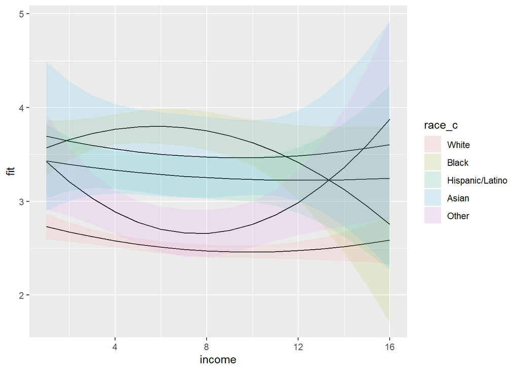

## Discussion

The results from the first model demonstrate that, across all races combined, Dahl’s model still holds; there is a statistically significant relationship between income and centrality of race to identity. Specifically, the negative sign on the coefficient of income demonstrates that as income increases, there is, in fact, the observed decrease in the centrality of race to identity. The second model shows that the introduction of education statistically significantly decreases the centrality of an individual’s racial identity, as does being an Independent, from the intercept reference category of Democrats. However, the same cannot conclusively be said about being a Republican, as the corresponding value fails a p-value test. This being said, the fact that the coefficient on income is still negative, and statistically significant, implies that even with the introduction of the potentially confounding covariate factors, increasing income still has a statistically significant negative effect on centrality of race to identity. In other words, even taking into account the potential effect that education and partisanship have on an individual’s perception of the centrality of their race to their identity, as their income increases that perception is still predicted to decrease. Finally, the third model demonstrates that the introduction of the interaction between racial group and income, which is intended to gauge the effect that being a particular racial group has on the slope of the income line, results in different statistically significant intercept points from the reference category of White Democrats. Interestingly, the data seems to suggest that being Republican actually increases the centrality of an individual’s race to their identity, with Black Republicans having the highest statistically significant intercept point for centrality of race when holding the slope constant, followed by Asian and Hispanic/Latino Republicans. Black, Asian, and Hispanic/Latino Democrats follow in that order. According to the data. Black, Asian, and Hispanic/Latino Independents have the lowest intercept for centrality of race to identity when holding the slope on income constant. However, the effect that being particular racial categories has on the coefficient of income of the reference category is miniscule, and, unfortunately, not statistically significant insofar as none of those coefficients pass a p-value test. Thus, the extent to which being a particular racial group affects the extent to which income affects centrality of race to identity cannot be conclusively determined based on this data. Perhaps, given the incredibly large proportion of White respondents to this sample, there was not enough data to provide conclusive evidence regarding this interaction. Perhaps, then, a future paper should draw its sample from data of a large pool of minority voters, as opposed to drawing a sample of data such that the sample is proportional to the voter outcome in 2018.

## Bibliography

1. ```
   Attkisson, Sharyl. "Report: An inside Look into African Americans Who Support Trump.” ABC3340, ABC, 10 Nov. 2019, https://abc3340.com/news/nation-world/an-inside-look-into-african-americans-who-support-trump.
   ```

2. ```
   Dahl, Robert Alan. Who Governs: Democracy and Power in American City. Yale University Press, 1961.
   ```

3. ```
   “Get The Data.” What the Hell Happened, Data for Progress, https://wthh.dataforprogress.org/get-the-data.
   ```

4. ```
   Owens, Candace. “Candace Owens (\@RealCandaceO).” Twitter, Twitter, June 2017, https://twitter.com/RealCandaceO?ref_src=twsrc^google|twcamp^serp|twgr^author.
   ```

## Code Appendix

```r
#######################
## Packages and options
  ## Easy way to look for and install missing packages and load them
  if (!require("pacman")){ install.packages("pacman") }
  pacman::p_load("knitr","mosaic","tidyverse","ggplot2","foreign","texreg")

  ## Set some default options R Markdown
  opts_chunk$set(tidy=TRUE,echo=F,results='hide',strip.white=TRUE,cache=FALSE,highlight=TRUE,width.cutoff=132,size='footnotesize',message=FALSE,warning=TRUE,comment=NA)

  # Default options in R
  options(digits=4,width=100,scipen=8)

  #Determine the output format of the document
  outputFormat   = opts_knit$get("rmarkdown.pandoc.to")

  #Figure and Table Caption Numbering, for HTML do it manually
  capTabNo = 1; capFigNo = 1;

  #Function to add the Table Number
  capTab = function(x){
    if(outputFormat == 'html'){
      x = paste0("Table ",capTabNo,". ",x)
      capTabNo <<- capTabNo + 1
    }; x
  }

  #Function to add the Figure Number
  capFig = function(x){
    if(outputFormat == 'html'){
      x = paste0("**Figure ",capFigNo,". ",x,"**")
      capFigNo <<- capFigNo + 1
    }; x
  }

  #for table function later
  library(sjPlot)
  library(sjmisc)
  library(sjlabelled)

  #for grid arrange later
  library(tidyverse)
  library(gridExtra)
  library(grid)
  library(png)
  library(downloader)
  library(grDevices)

#######################
## Data and Variables Section
  ## Load WTHH Data
  df <- read.csv(url("http://filesforprogress.org/datasets/wthh/DFP_WTHH_release.csv"))

  ##DEPENDENT VARIABLE, class integer
  df$race_imp <- df$RACE_IDENT #recoding just for simplicity

  ##INDEPENDENT VARIABLE, class integer
  df$income <- df$faminc_new
  df$income[df$income == 97] <- NA #recoding for NA's in income

  ##COVARIATE, class integer
  ##df$educ4 keep as is (High School or less, some college, college grad, postgrad)

  ##COVARIATE, class character
  df$pid3new <- df$pid7
  df$pid3new[df$pid3new >= 1 & df$pid3new <= 3] <- "Dem" #recoding pid7 for dem (factor 1)
  df$pid3new[df$pid3new == 4] <- "Indep" #recoding pid7 for indep (factor 2)
  df$pid3new[df$pid3new >= 5 & df$pid3new <= 7] <- "Repub" #recoding pid7 for repub (factor 3)
  df$pid3new[df$pid3new == 8] <- NA #changing pid7 Not Sure to NA

  ##COVARIATE, class character
  df$race_c <- df$race #recoding to character values
  df$race_c[df$race_c == 1] <- "White"
  df$race_c[df$race_c == 2] <- "Black"
  df$race_c[df$race_c == 3] <- "Hispanic/Latino"
  df$race_c[df$race_c == 4] <- "Asian"
  df$race_c[df$race_c == 8 | df$race_c == 5 | df$race_c == 6 | df$race_c == 7] <- "Other" #recoding rest to Other

  df$race_c <- factor(df$race_c, levels = c("White", "Black", "Hispanic/Latino", "Asian", "Other")) #releveling factors to make white the excluded category


  race_imp_smry <- summary(df$race_imp)
  race_imp_sd <- sd(df$race_imp, na.rm = T)
  race_imp_smryfull <- c(race_imp_smry, sd = race_imp_sd)

  income_smry <- summary(df$income)
  income_sd <- sd(df$income, na.rm = T)
  income_smryfull <- c(income_smry, sd = income_sd)

  educ4_smry <- c(summary(df$educ4), "NA's" = 0)#no na's, need to add a value for na for rbind
  educ4_sd <- sd(df$educ4, na.rm = T)
  educ4_smryfull <- c(educ4_smry, sd = educ4_sd)

  tab1 <- rbind(race_imp_smryfull, income_smryfull, educ4_smryfull)

  ##describing pid3new and race_c separately in terms of percentages

  tab2 <- rbind(summary(as.factor(df$pid3new)), prop.table(summary(as.factor(df$pid3new))))
  tab3 <- rbind(summary(as.factor(df$race_c)), prop.table(summary(as.factor(df$race_c))))



  ##identity plot
  p1 <- data.frame(prop.table(summary(as.factor(df$pid3new))))
  colnames(p1) <- c("Proportion")
  p1$Partisanship <- rownames(p1)

  ##race plot
  p2 <- data.frame(prop.table(summary(as.factor(df$race_c))))
  colnames(p2) <- c("Proportion")
  p2$Race <- rownames(p2)

  #race c vs partisanship

  t <- table(df$race_c, df$pid3new)
  r <- c(rep("White", 3), rep("Black", 3), rep("Hispanic/Latino", 3), rep("Asian", 3), rep("Other", 3))
  r
  p <- c(rep(c("Dem", "Indep", "Repub"), 5))
  p
  v <- c(as.numeric(unlist(t[1,])),as.numeric(unlist(t[2,])),as.numeric(unlist(t[3,])),as.numeric(unlist(t[4,])),as.numeric(unlist(t[5,])))
  v
  p3 <- data.frame(r,p,v)

  kable(tab1)

  kable(tab2)
  ggplot(data = p1,
         mapping = aes(x = Partisanship , y = Proportion))+
    geom_col()

  kable(tab3)
  ggplot(data = p2,
         mapping = aes(x = Race, y = Proportion))+
    geom_col()

  ##income plot (race vs income)

  ggplot(data = df,
         mapping = aes(x = race_c, y = income))+
    geom_boxplot()

  # Stack race c vs partisanship
  ggplot(p3, aes(fill=p, y=v, x=r)) +
      geom_bar(position="stack", stat="identity")+
      theme(axis.text.x=element_text(angle=90,hjust=1,vjust=0.5))->plot1

  #non white race c vs partisanship for clarity
  ggplot(p3[4:15,], aes(fill=p, y=v, x=r)) +
      geom_bar(position="stack", stat="identity")+
      theme(axis.text.x=element_text(angle=90,hjust=1,vjust=0.5))->plot2

  grid.arrange(plot1, plot2, ncol=2)

#######################
## Analysis and Results Section
  ##first lm
  m1 <- lm(race_imp ~ income, df)
  m1
  ##introducing covariates, second lm
  m2 <- lm(race_imp ~ income +pid3new + educ4, df)
  m2

  ##introducing intersection w/ race_c, third lm
  m3 <- lm(race_imp ~ income * race_c + educ4 + pid3new, df)
  m3


  tab_model(m1,
            dv.labels = "ml",
            show.se = TRUE)

  htmlreg(list(m1,m2,m3), digits = 4)


  ##what if the relationship isnt linear, but instead is quadratic:

  m4 <- lm(race_imp ~ (income + I(income^2)) * race_c + educ4 + pid3new, df)

  ##analysis stats
  summary(m4)
  confint(m4)

  # PRedictions from model
  pred_df <- data.frame(
    expand.grid(
      income = 1:16,
      race_c = levels(df$race_c),
      educ4 = mean(df$educ4, na.rm=T),
      pid3new = "Repub"

    )
  )
  df$pid3new
  pred_df <- cbind(pred_df, predict(m4, pred_df, interval="confidence"))
  pred_df %>%
    ggplot(aes(income,fit, fill=race_c))+
    geom_line()+
    geom_ribbon(aes(ymin=lwr,ymax=upr) ,alpha =.1)
```